# Programming with models (2): Inspecting model structure (state-space model example)

NIMBLE training materials module

NIMBLE Development Team

# Outline

In this module, we’ll learn how to query a model about its graph.

*model-generic programming = querying a model’s graph + operating a model*

Specifically, we’ll learn:

- about topological ordering of nodes and why it matters.
- how to determine the dependencies (or children) of one or more nodes, and
  - what different kinds of dependencies mean.
- how to expand node names.
- how to determine node categories such as *top-level nodes, latent-state nodes, and data nodes*.
- how NIMBLE sometimes inserts *lifted nodes* into a model and what that means for you.
- how to determine the variables in a model.

```r
library(igraph)
ssmSmallCode <- nimbleCode({
# Priors and constraints
logN.est[1] ~ dnorm(5.6, 0.01)       # Prior for initial population size
mean.r ~ dnorm(1, 0.001)             # Prior for mean growth rate
sigma.proc ~ dunif(0, 1)             # Prior for sd of state process
sigma.obs ~ dunif(0, 1)              # Prior for sd of observation process

# Likelihood
# State process
for (t in 1:(T-1)){
   r[t] ~ dnorm(mean.r, sd = sigma.proc)
   logN.est[t+1] <- logN.est[t] + r[t]
   }
# Observation process
for (t in 1:T) y[t] ~ dnorm(logN.est[t], sd = sigma.obs)

})


pyears <- 6 # Number of future years with predictions
hm <- c(271, 261, 309, 318, 231, 216, 208, 226, 195, 226, 233, 209, 226, 192, 191, 225,
        245, 205, 191, 174, rep(NA, pyears))
year <- 1990:(2009 + pyears)

# Bundle data
bugs.data <- list(y = log(hm), T = length(year))
## NIMBLE will handle y as data, T as a constant

ssmSmall <- nimbleModel(ssmSmallCode, constants = list(T = 5),
                        data = list(y = bugs.data$y[1:5]))
```

```
## defining model...
```

```
## building model...
```

```
## setting data and initial values...
```

```
## checking model...   (use nimbleModel(..., check = FALSE) to skip model check)
```

```
## NAs were detected in model variables: logN.est, logProb_logN.est, mean.r, logProb_mean.r, sigma.proc, logProb_sigma.proc, sigma.obs, logProb_sigma.obs, r, logProb_r, logProb_y.
```

```
## model building finished
```

# Topological ordering of nodes and why it matters.

Suppose we want to change the value of `r[3]` and update all relevant parts of the graph. (The meaning of “relevant” depends on our purpose of changing `r[3]`. In this case imagine we are making a Metropolis-Hastings (MCMC) proposal and need to calculate its acceptance probability.) The nodes that need to be updated are shown in red.

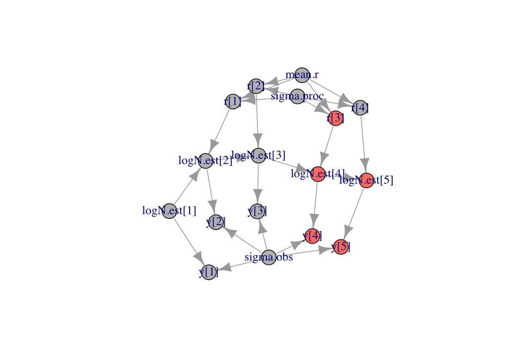

```r
## function drawGraph is defined in the R file for this module
drawGraph(ssmSmall, ssmSmall$getDependencies('r[3]'))
```

Note that **order matters**. If we calculated the log probability density of `y[4]` *before* calculating `logN.est[4]`, then `y[4]` would use the *old* value of `logN.est[4]`. That would be a mistake.

A valid order for calculations is called *topologically sorted*. Most of NIMBLE’s model-querying functions will return nodes in tologically sorted order.

# Inspecting the model: Querying graph dependencies

There are several kinds of dependencies that may be needed by different algorithms.

```r
ssmSmall$getDependencies('r[3]')
```

```
## [1] "r[3]"        "logN.est[4]" "logN.est[5]" "y[4]"        "y[5]"
```

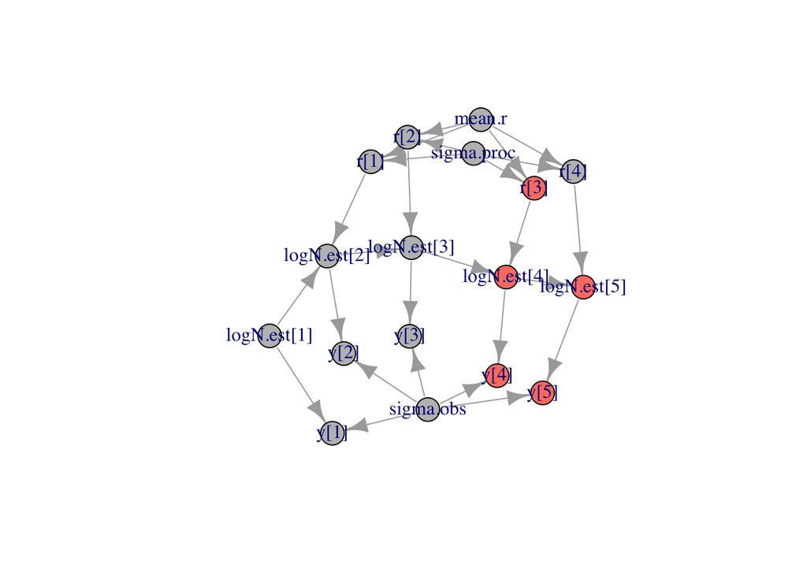

```r
drawGraph(ssmSmall, ssmSmall$getDependencies('r[3]'))
```

- Stochastic dependencies are needed for a Metropolis-Hastings MCMC sampler.
- *Deterministic dependencies* terminate at stochastic nodes but omit the stochastic nodes. These can be useful for implementing a particle filter.

```r
ssmSmall$getDependencies('r[3]', determOnly = TRUE)
```

```
## [1] "logN.est[4]" "logN.est[5]"
```

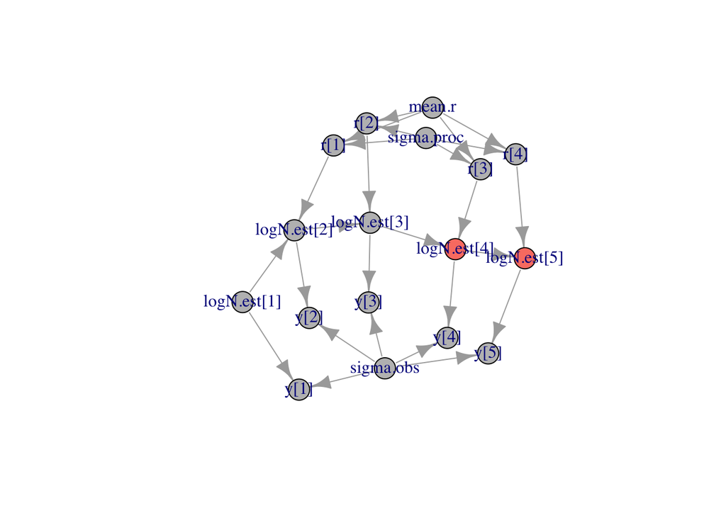

```r
drawGraph(ssmSmall, ssmSmall$getDependencies('r[3]', determOnly = TRUE))
```

- Other ways to control the dependency query can be found by

```r
args(ssmSmall$getDependencies)
```

```
## function (nodes, omit = character(), self = TRUE, determOnly = FALSE,
##     stochOnly = FALSE, includeData = TRUE, dataOnly = FALSE,
##     includeRHSonly = FALSE, downstream = FALSE, returnType = "names",
##     returnScalarComponents = FALSE)
## NULL
```

```r
## or help(modelBaseClass)
```